# Исследование объявлений о продаже квартир

#### Поиск выбивающихся значений

Проанализировав диаграммы каждого столбца делаю выводы:

- Цена. Имеются единичные объекты стоимость в несколько миллионов. Это наврятли аномалии однако их можно исключить. Удалю значения больше 60 миллионов
- Высота потолков. Много очень высоких значений. Предположим, что это связанно с тем, что это на самом деле вещественные значения. А значения менее полутора метров удалю так как они очевидно аномальны.
- Площадь. Значения похожи на верные, так как им соответствует очень высокая цена.
- Этажность. Большинство квартир находятся ниже 30 этажа. Но этажность доходит до 60. Отбросим все значения этажности больше 30.
- Дней размещено объявление. Значения доходят до 4 лет. Нужно соотнести это с значениями в дате размещения.

```python
#plt.ylim(0,15)
#data.boxplot(column='ceiling_height', figsize=(20,20))
#x = data.sort_values(by='total_area', ascending=False)
#display(x.head(20))
#data.info()
#display(data.boxplot(column='total_images', figsize=(5,10)))

#display(data.boxplot(column='rooms', figsize=(5,10)))
#display(data.boxplot(column='ceiling_height', figsize=(5,10)))
#display(data.boxplot(column='floors_total', figsize=(5,10)))
#display(data.boxplot(column='living_area', figsize=(5,10)))
#display(data.boxplot(column='floor', figsize=(5,10)))

#data.hist(figsize=(15, 30), bins=30, grid=True)
#Проверял гипотезы выше
```

```python
display(data['first_day_exposition'].min(), data['first_day_exposition'].max())
```

```
Timestamp('2014-11-27 00:00:00')
```

```
Timestamp('2019-05-03 00:00:00')
```

В самом деле объявления могут быть размещены 4 года. Время размещения трогать не буду.

```python
data.info()
```

```
<class 'pandas.core.frame.DataFrame'>
RangeIndex: 23699 entries, 0 to 23698
Data columns (total 22 columns):
 #   Column                Non-Null Count  Dtype
---  ------                --------------  -----
 0   total_images          23699 non-null  int64
 1   last_price            23699 non-null  int64
 2   total_area            23699 non-null  float64
 3   first_day_exposition  23699 non-null  datetime64[ns]
 4   rooms                 23699 non-null  int64
 5   ceiling_height        14504 non-null  float64
 6   floors_total          23613 non-null  float64
 7   living_area           21796 non-null  float64
 8   floor                 23699 non-null  int64
 9   is_apartment          23699 non-null  bool
 10  studio                23699 non-null  bool
 11  open_plan             23699 non-null  bool
 12  kitchen_area          21421 non-null  float64
 13  balcony               23699 non-null  int64
 14  locality_name         23650 non-null  object
 15  airports_nearest      18157 non-null  float64
 16  cityCenters_nearest   18180 non-null  float64
 17  parks_around3000      23699 non-null  int64
 18  parks_nearest         8079 non-null   float64
 19  ponds_around3000      23699 non-null  int64
 20  ponds_nearest         9110 non-null   float64
 21  days_exposition       20518 non-null  float64
dtypes: bool(3), datetime64[ns](1), float64(10), int64(7), object(1)
memory usage: 3.5+ MB
```

```python
def ceiling_height_fix(row):
    #Если высота потолков более 10 метров то делит ее на 10
    try:
        if row > 15:
            return row / 10
        else:
            return row
    except:
        return row

data['ceiling_height'] = data['ceiling_height'].apply(ceiling_height_fix) #применяем функцию

data = data.query('(last_price < 60000000) and (floors_total <= 30) and ((ceiling_height > 1.5) or (ceiling_height.isna()))') #убирает строки с выбросами
```

### Посчитайте и добавьте в таблицу новые столбцы

```python
def floor_type_set(row):
    #функция делит квартиры по типу этажа на три группы
    try:
        fl = row['floor']
        fl = float(fl)
        last_fl = row['floors_total']
        if fl == 1:
            return 'первый'
        elif fl == last_fl:
            return 'последний'
        else:
            return 'другой'
    except:return 'другой'

def m_to_km(row):
    #конвертирует метры в километры
    try:
        x = row / 1000
        x = round(x)
        return x
    except: return row
```

```python
#Цена одного квадратного метра
data['price_per_meter'] = data['last_price'] / data['total_area']
data['price_per_meter'] = data['price_per_meter'].round(0)

#День публикации объявления
data['weekday'] = data['first_day_exposition'].dt.weekday

#Месяц публикации объявления
#arrivals['month'] = pd.DatetimeIndex(arrivals['date_datetime']).month
data['month'] = data['first_day_exposition'].dt.month

#Год публикации объявления
data['year'] = data['first_day_exposition'].dt.year

#тип этажа
data['floor_type'] = data.apply(floor_type_set, axis=1)

#Расстояние до центра в километрах
data['city_centers_nearest_km'] = data['cityCenters_nearest'].apply(m_to_km)
```

### Проведите исследовательский анализ данных

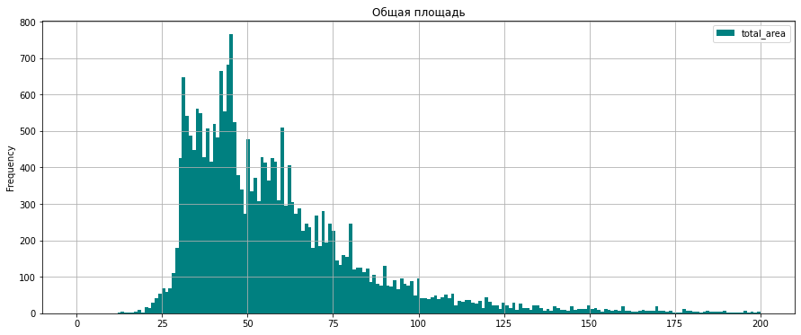

```python
data.plot(kind='hist',y='total_area',bins=201, title='Общая площадь', grid=True, figsize=(15, 6), color='teal', range=(0,200))
```

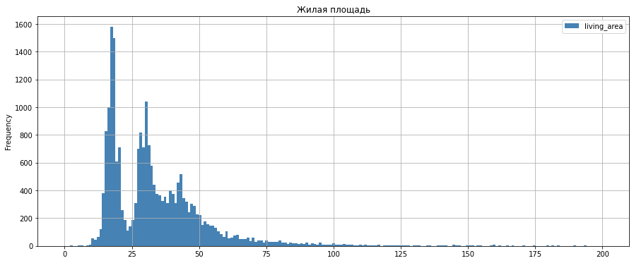

```python
data.plot(kind='hist',y='living_area',bins=201, title='Жилая площадь', grid=True, figsize=(15, 6), color='steelblue',range=(0,200))
```

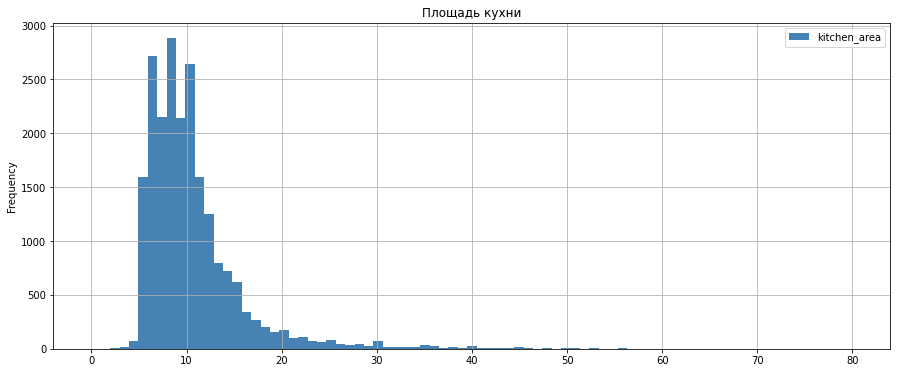

```python
data.plot(kind='hist',y='kitchen_area',bins=81, title='Площадь кухни', grid=True, figsize=(15, 6), color='steelblue', range=(0,80))
```

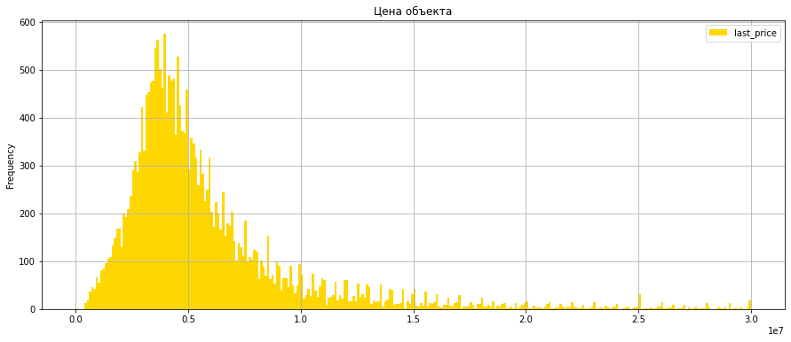

```python
data.plot(kind='hist',y='last_price',bins=300, title='Цена объекта', grid=True, figsize=(15, 6), color='gold', range=(0,30000000))
```

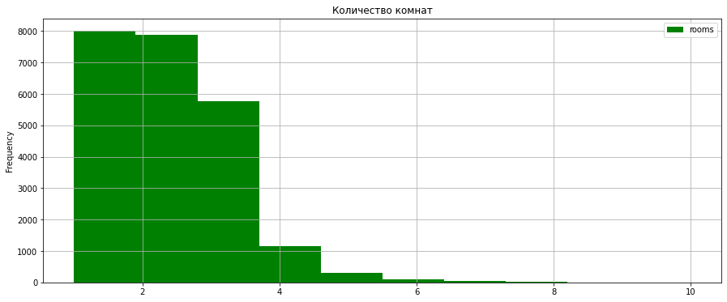

```python
data.plot(kind='hist',y='rooms',bins=10, title='Количество комнат', grid=True, figsize=(15, 6), color='g',range=(1,10))
```

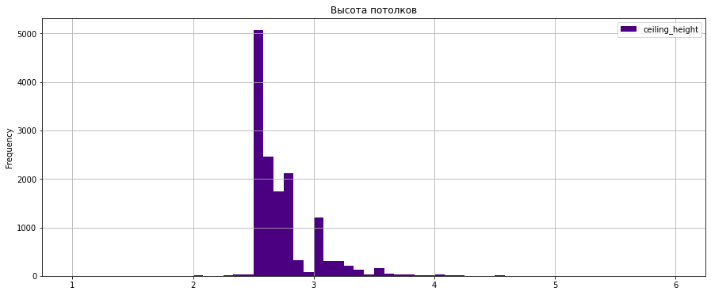

```python
data.plot(kind='hist',y='ceiling_height',bins=60, title='Высота потолков', grid=True, figsize=(15, 6), color='indigo', range=(1,6))
```

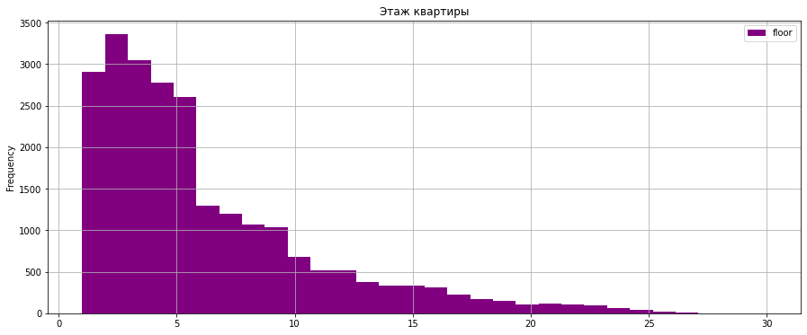

```python
data.plot(kind='hist',y='floor',bins=30, title='Этаж квартиры', grid=True, figsize=(15, 6), color='purple', range=(1,30))
```

```
Тип этажа квартиры
```

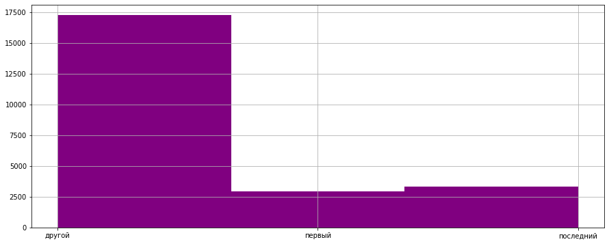

```python
print('Тип этажа квартиры')
data['floor_type'].hist(bins=3, grid=True, figsize=(15, 6), color='purple')
```

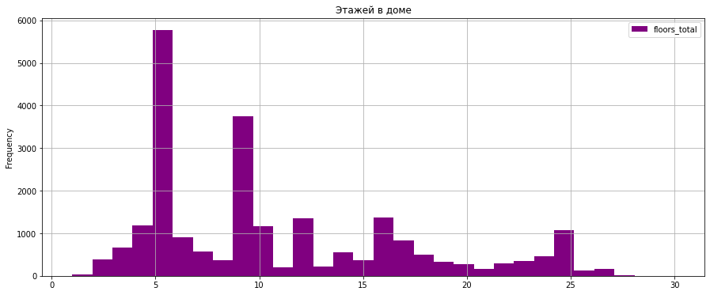

```python
data.plot(kind='hist',y='floors_total',bins=30, title='Этажей в доме', grid=True, figsize=(15, 6), color='purple', range=(1,30))
```

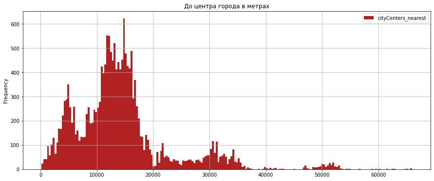

```python
data.plot(kind='hist',y='cityCenters_nearest',bins=200, title='До центра города в метрах', grid=True, figsize=(15, 6), color='firebrick')
```

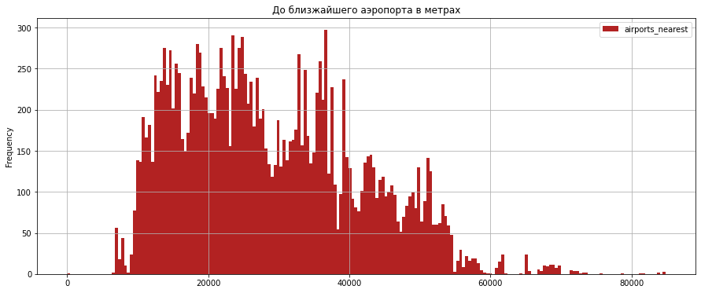

```python
data.plot(kind='hist',y='airports_nearest',bins=200, title='До близжайшего аэропорта в метрах', grid=True, figsize=(15, 6), color='firebrick')
```

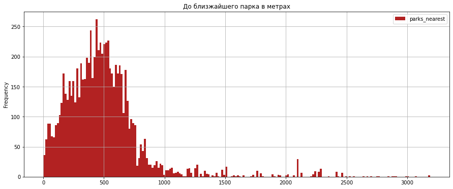

```python
data.plot(kind='hist',y='parks_nearest',bins=200, title='До близжайшего парка в метрах', grid=True, figsize=(15, 6), color='firebrick')
```

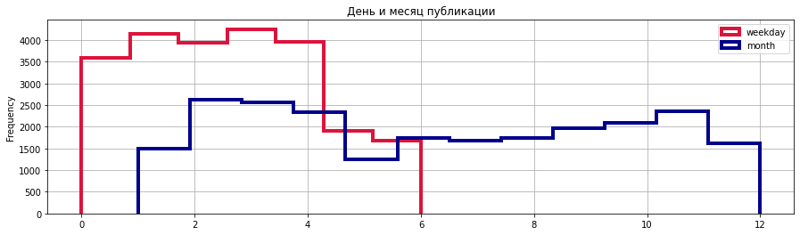

```python
ax = data.plot(kind='hist',y='weekday',bins=7, grid=True, figsize=(15, 6), color='crimson', histtype='step', linewidth=4)
data.plot(kind='hist',y='month',bins=12, title='День и месяц публикации', grid=True, figsize=(15, 4), color='darkblue', histtype='step', ax=ax, linewidth=4)
```

#### 4.2 Скорость продажи квартир

```
count    20332.000000
mean       180.290183
std        219.265182
min          1.000000
25%         45.000000
50%         95.000000
75%        231.000000
max       1580.000000
Name: days_exposition, dtype: float64
```

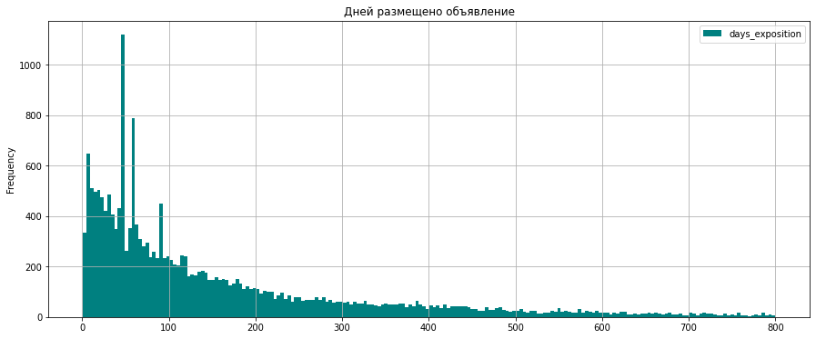

```python
data.plot(kind='hist',y='days_exposition',bins=200, title='Дней размещено объявление', grid=True, figsize=(15, 6), color='teal',range=(1,800))
display(data['days_exposition'].describe())
```

#### Факторы, влияющие на стоимость

Нужно проанализировать, зависит ли цена от:

- общей площади;
- жилой площади;
- площади кухни;
- количества комнат;
- этажа, на котором расположена квартира (первый, последний, другой);
- даты размещения (день недели, месяц, год).

```
'Корреляция:  0.7417846097037664'
```

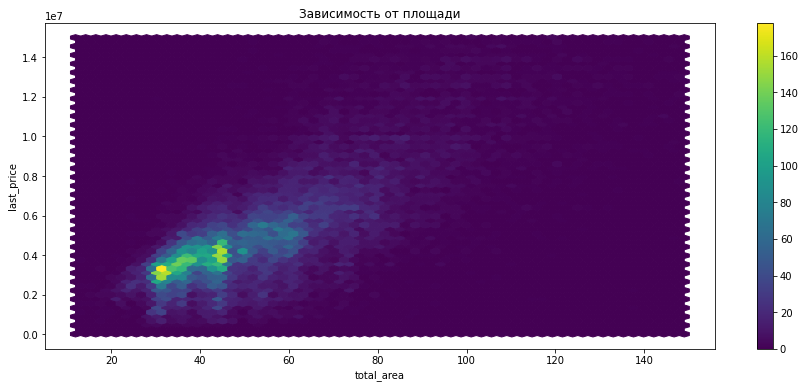

```python
price_table = data.query('last_price < 15000000')#отрезает область с малым количеством значений для красоты графика
price_table = price_table.query('total_area < 150')

price_table.plot(x='total_area', y='last_price', kind='hexbin', gridsize=60, title='Зависимость от площади', grid=False, figsize=(15, 6), alpha=1, sharex=False, cmap="viridis")
cor = price_table['last_price'].corr(price_table['total_area'])
display(f'Корреляция:  {cor}')
```

```
'Корреляция:  0.6047694653660265'
```

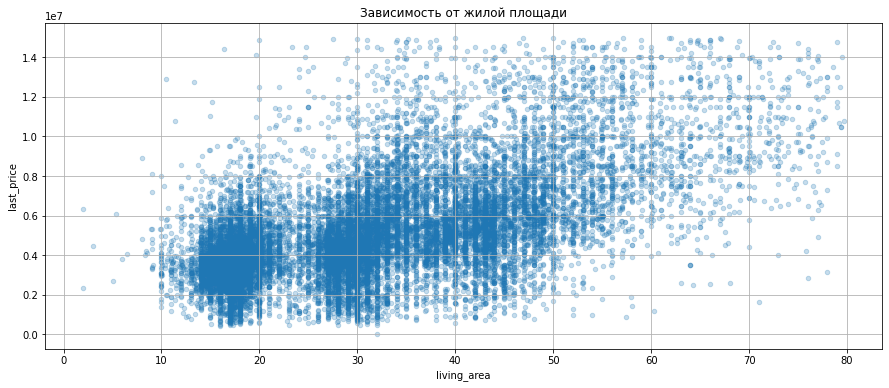

```python
price_table = price_table.query('living_area < 80')
#price_table.plot(x='living_area', y='last_price', kind='hexbin', gridsize=60, title='Зависимость от жилой площади', grid=False, figsize=(15, 6), alpha=1, sharex=False, cmap="viridis")
price_table.plot(x='living_area', y='last_price', kind='scatter', title='Зависимость от жилой площади', grid=True, figsize=(15, 6), alpha=0.25)
cor = price_table['last_price'].corr(price_table['living_area'])
display(f'Корреляция:  {cor}')
```

```
'Корреляция:  0.5220771926256224'
```

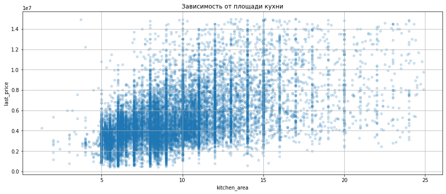

```python
price_table = price_table.query('kitchen_area < 25')
#price_table.plot(x='kitchen_area', y='last_price', kind='hexbin', gridsize=60, title='Зависимость от жилой площади', grid=False, figsize=(15, 6), alpha=1, sharex=False, cmap="viridis")
price_table.plot(x='kitchen_area', y='last_price', kind='scatter', title='Зависимость от площади кухни', grid=True, figsize=(15, 6), alpha=0.2)
cor = price_table['last_price'].corr(price_table['kitchen_area'])
display(f'Корреляция:  {cor}')
```

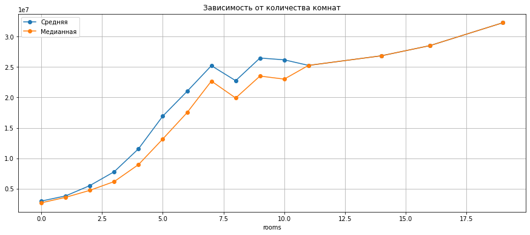

```python
rooms_pivot = data.pivot_table(index='rooms', values='last_price', aggfunc=['mean','median'])
rooms_pivot.columns = ['Средняя', 'Медианная']
rooms_pivot.plot(title='Зависимость от количества комнат', style='o-', grid=True, figsize=(15, 6))
```

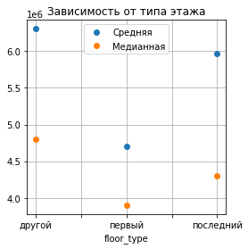

```python
floors_type_pivot = data.pivot_table(index='floor_type', values='last_price', aggfunc=['mean','median'])
floors_type_pivot.columns = ['Средняя', 'Медианная']
floors_type_pivot.plot(title='Зависимость от типа этажа', style='o', grid=True, figsize=(4, 4))
```

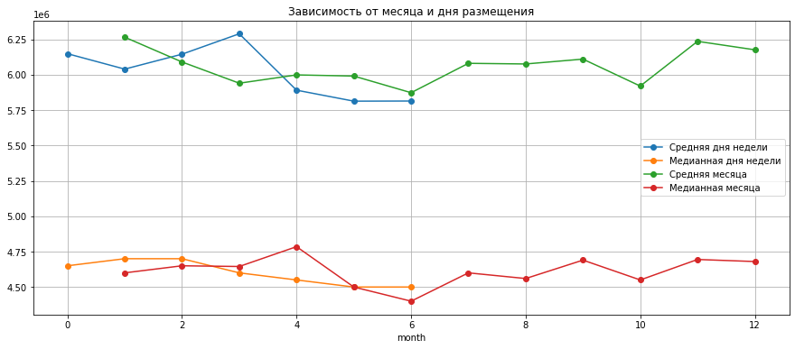

```python
date_pivot = data.pivot_table(index='weekday', values='last_price', aggfunc=['mean','median'])
date_pivot.columns = ['Средняя дня недели', 'Медианная дня недели']
#display(date_pivot)
date_plot = date_pivot.plot(title='С', style='o-', grid=True, figsize=(15, 6))

month_pivot = data.pivot_table(index='month', values='last_price', aggfunc=['mean','median'])
month_pivot.columns = ['Средняя месяца', 'Медианная месяца']
month_pivot.plot(style='o-', grid=True, figsize=(15, 6), ax=date_plot, title='Зависимость от месяца и дня размещения')
```